# Statistics for Data Science with `R`

# Introduction to Linear Models

```r
require(ggplot2)
require(qdata)
require(dplyr)
```

Let us consider a simple relation between height and weight in a sample of young people:

```r
data(ds)
str(ds)
```

```
## Classes 'tbl_df', 'tbl' and 'data.frame':    200 obs. of  3 variables:
##  $ height: num  152 152 172 159 171 ...
##  $ weight: num  54.5 62.6 61.4 62.9 64.5 ...
##  $ gender: Factor w/ 2 levels "F","M": 1 1 1 1 1 1 1 1 1 1 ...
```

```r
head(ds)
```

```
## # A tibble: 6 x 3
##     height   weight gender
##      <dbl>    <dbl> <fctr>
## 1 152.4451 54.45182      F
## 2 152.3823 62.56590      F
## 3 172.2429 61.43563      F
## 4 158.9386 62.93164      F
## 5 170.7935 64.51634      F
## 6 183.1107 74.17911      F
```

Each row of above fictitious `ds` dataframe contains height (in cm) weight (in Kg), and gender of a different young person.  
Now, one might want to find a simple (or **smooth**) numerical relation (a **regression**) between `height` and `weight` measures, where `weight` will depend on `height`.

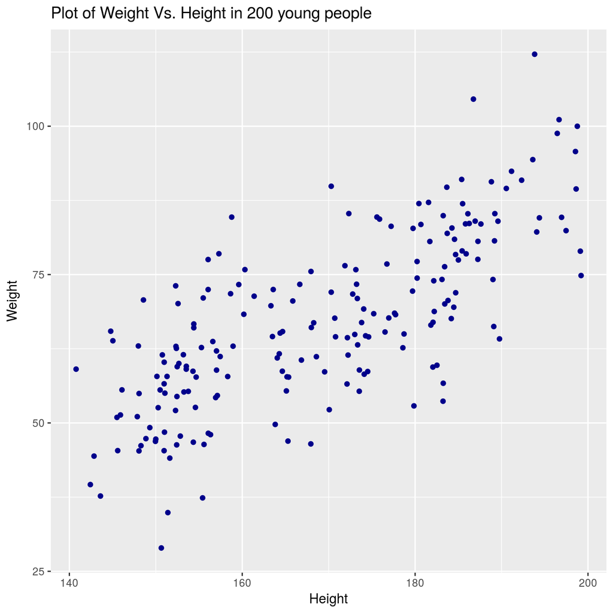

Relation between Weight and Height of 200 young people

```r
ggp <- ggplot(data=ds,mapping = aes(x=height, y=weight)) +
  geom_point(colour="darkblue") +
  xlab("Height") + ylab("Weight") +
  ggtitle("Plot of Weight Vs. Height in 200 young people")

print(ggp)
```

In other words, one might want to draw a smooth line that “best approximates” the causal relation between `height` and `weight` (i.e., the height influences the weight).

Note that the relation might be really simple, as finding a simple “central value” (i.e., when one hypotesizes that `weight` does not change when varying the height); in this case the “best” smooth line could be the mean of `weight` values)

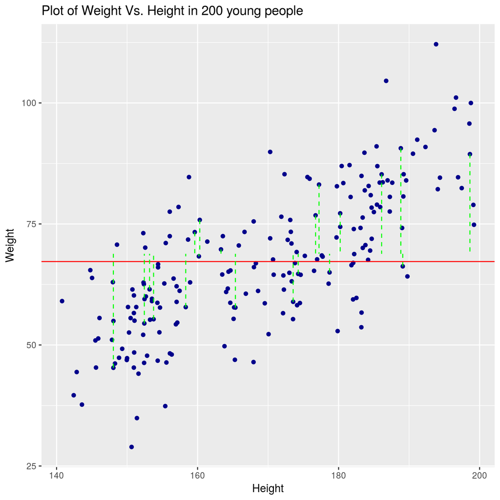

Relation between Weight and Height in 200 young people with ‘best constant model’

```r
ds2 <- ds %>% slice(c(1,1:20*10))
ds2 <- ds2 %>% mutate(x1=height, x0=height, y0=weight, y1=mean(weight))

ggp <- ggplot(data=ds,mapping = aes(x=height, y=weight)) +
  geom_point(colour="darkblue") +
  geom_hline(yintercept = mean(ds$weight), colour="red") +
  geom_segment(data=ds2,mapping = aes(x=x0, xend=x1, y=y0, yend=y1), colour="green", linetype=2) +
  xlab("Height") + ylab("Weight") +
  ggtitle("Plot of Weight Vs. Height in 200 young people")

print(ggp)
```

or the relation might be a few more complex, as a straight line of type (see next graph)
$$y=\beta_0+ \beta_1 \cdot x$$

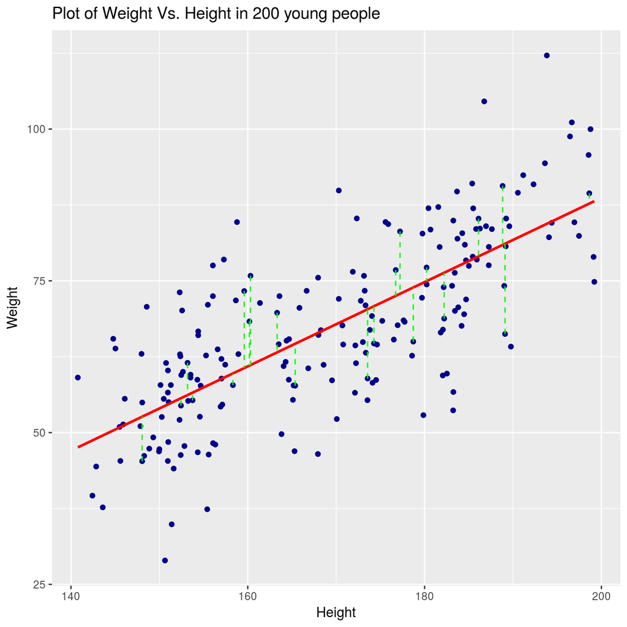

Relation between Weight and Height in 200 young people with best straight line model

```r
ds1 <- ds %>% arrange(height)
md <- lm(weight~height,data=ds1)
ds2 <- ds2 %>% mutate(y1=predict(md,newdata=ds2))

ggp <- ggplot(data=ds,mapping = aes(x=height, y=weight)) +
  geom_point(colour="darkblue") +
  geom_smooth(method = "lm",se = FALSE, colour="red") +
  geom_segment(data=ds2,mapping = aes(x=x0, xend=x1, y=y0, yend=y1), colour="green", linetype=2) +
  xlab("Height") + ylab("Weight") +
  ggtitle("Plot of Weight Vs. Height in 200 young people")

print(ggp)
```

or also more complex.

Anyway, in either above cases the line is estimated by using the so-called “least squares” method: the “best” line is the one for which the sum of squares of differences between the points and line itself is minimum.

In first model, the “level” for which one can attain the minimum of sum of squares of distance of points from line is at the average of `weight` values ($\overline{y}$). The dashed green lines represent the distances of some observed points from the “best” (estimated) line.

In second model, the result of application of least-squares method is a few more complex, but can be obtained in closed form, as:

$$\begin{cases}
\hat\beta_1=\dfrac{\sum_{i=1}^n(x_i-\overline{x})(y_i-\overline{y})}{\sum_{i=1}^n(x_i-\overline{x})^2} \\
\hat\beta_0=\overline{y}-\hat\beta_1 \overline{x}
\end{cases}$$

where $\hat\beta_0$ and $\hat\beta_1$ represent, respectively, the estimates of $\beta_0$ and $\beta_1$, $n$ is the number of people in sample (the sample size), and $\overline{x}$ and $\overline{y}$ represent, respectively, the arithmetic mean of `height` and the arithmetic mean of `weight` values.

The least-squares method may be seen as a particular case of the more general **Maximum Likelihood** method to data for which the Normality assumption may be applied (see “Some theory on Linear Models” chapter).

However notice that least-squares method by itself does not give information about the “better” model: in above examples, least-squares estimates are available for the “only-mean” model as well as for the straight line model, but no information about the preferable model is returned by the least-squares. Some tests can be used to choose the best model (in next chapters we will give information about that).

Finally, the relation can be more complex again: for example, a different line for male and female people may be estimated (see next Figure).

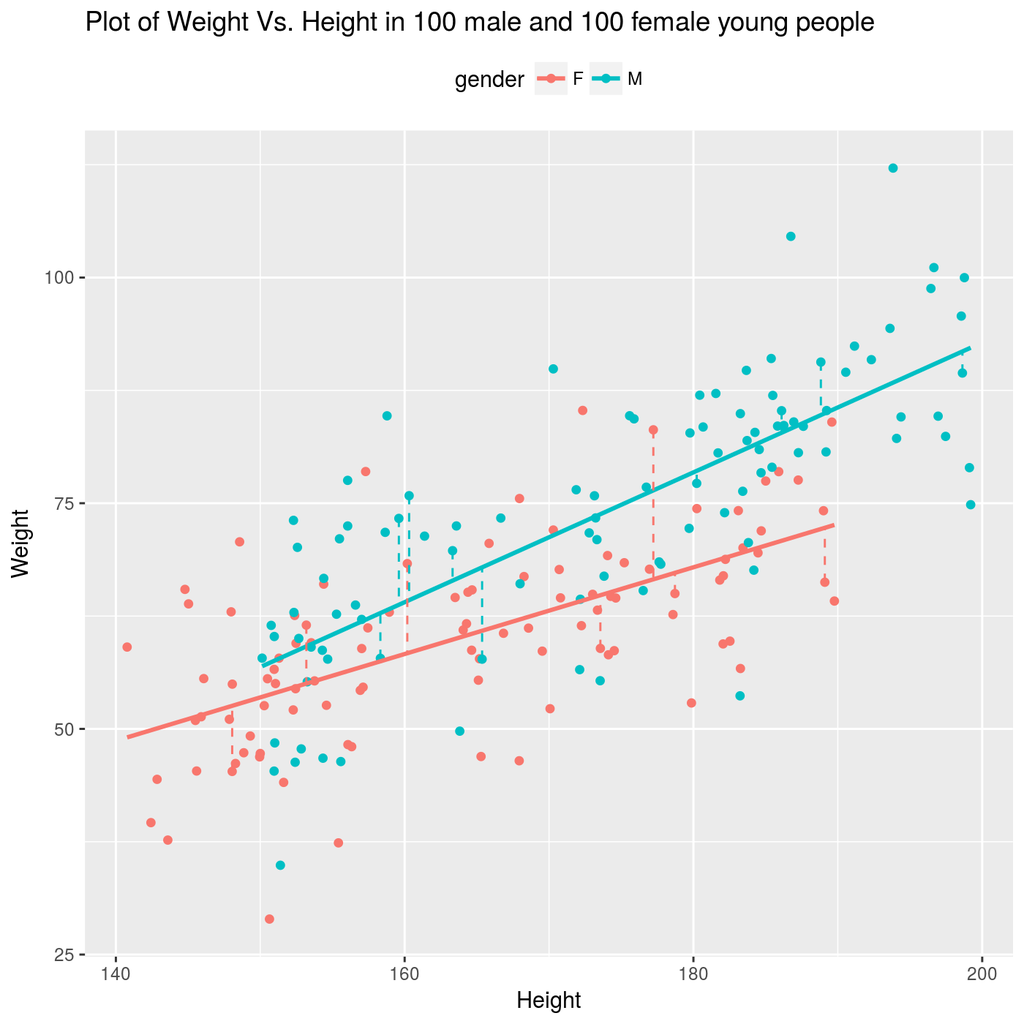

Relation between Weight and Height in 100 male and 100 female young people

```r
md <- lm(weight~height*gender,data=ds1)
ds2 <- ds2 %>% mutate(y1=predict(md,newdata=ds2))

ggp <- ggplot(data=ds,mapping = aes(x=height, y=weight, colour=gender)) +
  geom_point() +
  geom_smooth(mapping = aes(colour=gender), method = "lm",se = FALSE ) +
  geom_segment(data=ds2,mapping = aes(x=x0, xend=x1, y=y0, yend=y1, colour=gender), linetype=2) +
  xlab("Height") + ylab("Weight") +
  ggtitle("Plot of Weight Vs. Height in 100 male and 100 female young people")+
  theme(legend.position="top")

print(ggp)
```

This is because, roughly speaking, a model is said a **linear model** if unknown parameters and error term combine linearly, and not necessarily if the functional form, or relation, between independent and dependent variables is linear. In “Some Theory on Linear Model” chapter this topic is covered more thoroughly.

## Linear model formulae and functions in R

There are lots of different types of regression models in statistics but R mantains a coherent syntax for the estimation of all of them. Indeed, the common interface to fit a model in R is made of a call to the corresponding function with arguments `formula` and `data`.

Talking about linear regression models, the `lm` and `aov` functions are used in R to fit respectively linear regression and analysis of variance model and their syntax is:

```r
linear_model <- lm(formula, data)
anova_model <- aov(formula, data)
```

`formula` argument is a symbolic description of the model to be fitted, which has the form: `response variable ∼ predictor variables`. The variables involved in `formula` should be columns of a dataframe specied in `data` argument.

For example, consider `ds` dataset.

```r
str(ds)
```

```
## Classes 'tbl_df', 'tbl' and 'data.frame':    200 obs. of  3 variables:
##  $ height: num  152 152 172 159 171 ...
##  $ weight: num  54.5 62.6 61.4 62.9 64.5 ...
##  $ gender: Factor w/ 2 levels "F","M": 1 1 1 1 1 1 1 1 1 1 ...
```

To fit a linear model on the relation between `weight` and `height` of `ds` dataset, the sintax is:

```r
linear_model <- lm(formula = weight ~ height, data = ds)
```

In the following table some formulas examples are shown, where `y` represents the response variable, `x`, `x1`, `x2`, `x3` represent continuous variates, whereas upper case letters represent factors:

| **Expression** | **Description** |
| --- | --- |
| `y ~ x` | Simple regression |
| `y ~ 1 + x` | Explicit intercept |
| `y ~ -1 + x` | Through the origin |
| `y ~ x + I(x^2)` | Quadratic regression |
| `y ~ x1 + x2 + x3` | Multiple regression |
| `y ~ G + x1 + x2` | Parallel regressions |
| `y ~ G / (x1 + x2)` | Separate regressions |
| `sqrt(y) ~ x + I(x^2)` | Transformed |
| `y ~ G` | Single classification |
| `y ~ A + B` | Randomized block |
| `y ~ B + N * P` | Factorial in blocks |
| `y ~ x + B + N * P` | with covariate |
| `y ~ . -x1` | All variables except `x1` |
| `y ~ . + A:B` | Add interaction (`update`) |
| `Nitrogen ~ Times*(River/Site)` | More complex design |

The items in *Expression* column show several examples of formulas.  
An expression of the form `y ~` `model` is interpreted as a specification that the response `y` is modelled by a linear predictor specified symbolically by `model`. Such a model consists of a series of terms separated by `+` operators.

In next chapters, many examples of use of these functions will be then presented.

### Common R functions for inference

In following table the main functions used for linear model analysis are presented.

All the functions have to be applied on objects of class `lm` or class `aov`, obtained by calling, respectively,

`obj <- lm(formula)` or `obj <- aov(formula)`

| **Expression** | **Description** |
| --- | --- |
| `coef(obj)` | regression coefficients |
| `resid(obj)` | residuals |
| `fitted(obj)` | fitted values |
| `summary(obj)` | analysis summary |
| `predict(obj, newdata = ndat)` | predict for newdata |
| `deviance(obj)` | residual sum of squares |